# Walmart Sales Analysis

This project analyzes Walmart’s weekly sales data to identify store-level performance, seasonal patterns, and holiday effects.

**By:** All Rounder (Data Engineering & Security Student, DePaul University)  
**Date:** 23/10/2025  
**Project Description:**  
This notebook presents a comprehensive analysis of weekly sales data for Walmart stores. The objective is to explore store-level performance, detect seasonal patterns (especially holiday effects), and assess potential relationships between external factors and sales.

## 1. Introduction

In this project, I dive into the weekly sales dataset from Walmart, aiming to answer key questions such as:

- Which stores generate the most revenue and how large is the difference?
- How do sales fluctuate month by month and across years — are there seasonal or holiday-driven peaks?
- Do special holiday weeks result in significantly higher sales compared to non-holiday weeks?
- What is the relationship between sales and external numerical factors such as temperature, fuel price, CPI, and unemployment rate?

By systematically cleaning the data and performing targeted visualizations, this analysis will surface insights that may help in inventory planning, marketing strategies, and resource allocation for high-performing stores during peak periods.

## 2. Data Loading & Cleaning

This section covers:

- Loading the raw dataset into a pandas DataFrame
- Displaying basic information (shape, columns, missing values)
- Normalizing column names for consistency
- Handling missing values (e.g., setting empty sales to zero)
- Converting date strings to datetime format (including mixed formats)
- Dropping rows that are entirely empty
- Saving the cleaned dataset for further analysis

```python
import pandas as pd

# Load dataset
file_path = r"C:\Users\divya\Downloads\Walmart.csv"  # update if needed
df = pd.read_csv(file_path)

# Clean column names
df.columns = df.columns.str.strip().str.lower().str.replace(' ', '_')

# Handle missing values
if 'weekly_sales' in df.columns:
    df['weekly_sales'] = df['weekly_sales'].fillna(0)

# Convert date column to datetime
if 'date' in df.columns:
    df['date'] = pd.to_datetime(df['date'], errors='coerce', dayfirst=True)

# Drop fully empty rows
df.dropna(how='all', inplace=True)

# Save cleaned data
clean_path = r"C:\Users\divya\Downloads\Walmart_clean.csv"
df.to_csv(clean_path, index=False)
print("Cleaned dataset saved:", clean_path)

df.head()
```

```
Cleaned dataset saved: C:\Users\divya\Downloads\Walmart_clean.csv
```

|  | store | date | weekly_sales | holiday_flag | temperature | fuel_price | cpi | unemployment |
| --- | --- | --- | --- | --- | --- | --- | --- | --- |
| 0 | 1 | 2010-02-05 | 1643690.90 | 0 | 42.31 | 2.572 | 211.096358 | 8.106 |
| 1 | 1 | 2010-02-12 | 1641957.44 | 1 | 38.51 | 2.548 | 211.242170 | 8.106 |
| 2 | 1 | 2010-02-19 | 1611968.17 | 0 | 39.93 | 2.514 | 211.289143 | 8.106 |
| 3 | 1 | 2010-02-26 | 1409727.59 | 0 | 46.63 | 2.561 | 211.319643 | 8.106 |
| 4 | 1 | 2010-03-05 | 1554806.68 | 0 | 46.50 | 2.625 | 211.350143 | 8.106 |

## 3. Exploratory Data Analysis

In this section I conduct four main analyses:

### 3.1 Top Stores by Total Sales

I identify the top 10 stores in terms of cumulative weekly sales, which shows which locations contribute the most revenue.

### 3.2 Seasonal & Monthly Sales Trends

I analyze how total sales vary by month and year, looking for recurring patterns and seasonal peaks.

### 3.3 Holiday vs. Non-Holiday Weeks

I compare the distribution of weekly sales for holiday weeks versus non-holiday weeks to determine if holidays significantly boost sales.

### 3.4 Numeric Feature Correlations

I compute and visualize correlations between sales and other numerical features (temperature, fuel price, CPI, unemployment) to identify potential drivers of sales variation.

### *Code – Top Stores*

```
Top stores by total sales:
 store
20    3.013978e+08
4     2.995440e+08
14    2.889999e+08
13    2.865177e+08
2     2.753824e+08
10    2.716177e+08
27    2.538559e+08
6     2.237561e+08
1     2.224028e+08
39    2.074455e+08
Name: weekly_sales, dtype: float64
```

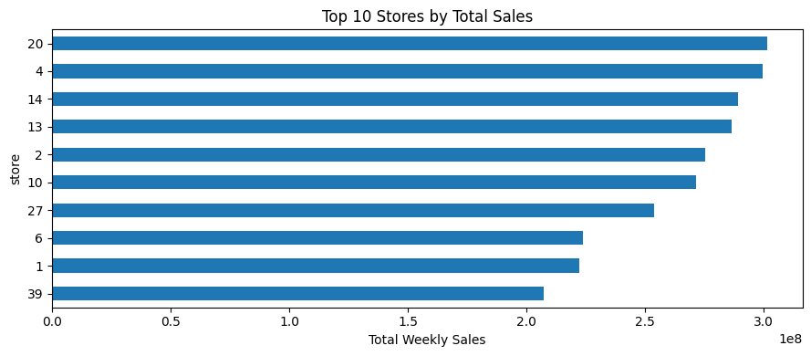

```python
import matplotlib.pyplot as plt

store_col = 'store'
sales_col = 'weekly_sales'

if store_col in df.columns and sales_col in df.columns:
    top_k = 10
    top_stores = df.groupby(store_col)[sales_col].sum().sort_values(ascending=False).head(top_k)
    print("Top stores by total sales:\n", top_stores)

    plt.figure(figsize=(9,4))
    top_stores.iloc[::-1].plot(kind='barh')
    plt.title(f"Top {top_k} Stores by Total Sales")
    plt.xlabel("Total Weekly Sales")
    plt.tight_layout()
    plt.show()
else:
    print("Missing store or sales columns.")
```

### Code – Monthly Trend

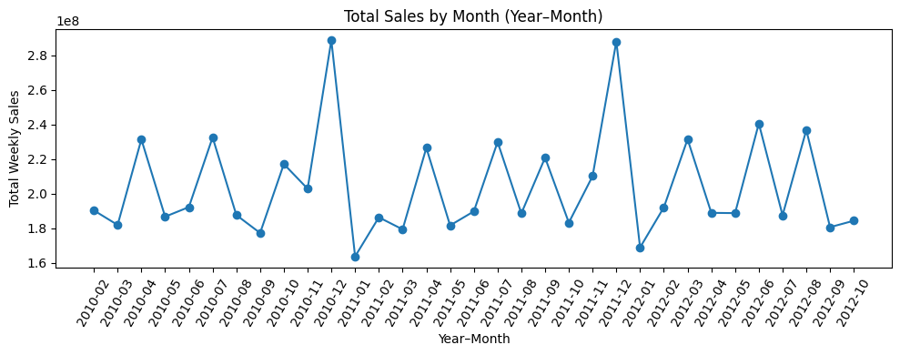

```python
if 'date' in df.columns and sales_col in df.columns:
    df['yearmonth'] = df['date'].dt.to_period('M')
    monthly_sales = df.groupby('yearmonth')[sales_col].sum().sort_index()

    plt.figure(figsize=(10,4))
    plt.plot(monthly_sales.index.astype(str), monthly_sales.values, marker='o')
    plt.xticks(rotation=60)
    plt.title('Total Sales by Month (Year–Month)')
    plt.xlabel('Year–Month')
    plt.ylabel('Total Weekly Sales')
    plt.tight_layout()
    plt.show()
else:
    print("Missing date or sales columns for monthly trend.")
```

#### Code – Holiday vs Non-Holiday

```
Holiday vs Non-Holiday weekly sales:
               count          mean      median            std
_holiday_num
0              5985  1.041256e+06   956211.20  558957.436147
1               450  1.122888e+06  1018538.04  627684.931884
```

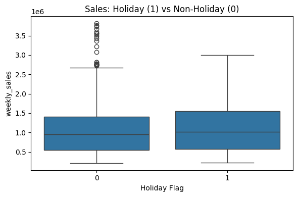

```python
import seaborn as sns

holiday_col = 'holiday_flag'  # change if your dataset uses a different name

if holiday_col in df.columns and sales_col in df.columns:
    df['_holiday_num'] = df[holiday_col].astype(int)
    stats = df.groupby('_holiday_num')[sales_col].agg(['count','mean','median','std'])
    print("Holiday vs Non-Holiday weekly sales:\n", stats)

    plt.figure(figsize=(6,4))
    sns.boxplot(x='_holiday_num', y=sales_col, data=df)
    plt.title('Sales: Holiday (1) vs Non-Holiday (0)')
    plt.xlabel('Holiday Flag')
    plt.ylabel(sales_col)
    plt.tight_layout()
    plt.show()
else:
    print("Missing holiday or sales columns.")
```

### Code – Correlation Heatmap

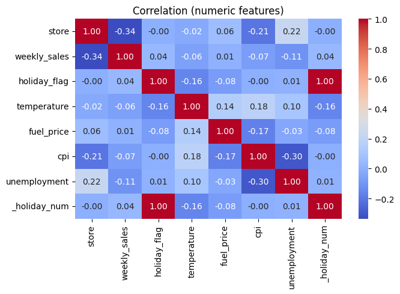

```python
num_df = df.select_dtypes(include='number')

if not num_df.empty:
    corr = num_df.corr()
    plt.figure(figsize=(7,5))
    sns.heatmap(corr, annot=True, fmt=".2f", cmap='coolwarm')
    plt.title('Correlation (numeric features)')
    plt.tight_layout()
    plt.show()
else:
    print("No numeric columns found for correlation.")
```

## 5. Conclusions & Recommendations

- **Inventory planning:** Prioritize stocking for top stores ahead of holiday peaks.
- **Marketing strategies:** Allocate more promotional resources to the high-performing stores and during the Nov-Dec period.
- **Resource allocation:** Consider reducing investment in under-performing stores or improving their performance through targeted actions.

Given the weak correlation with macro-economic variables, focus should remain on store-specific and seasonal initiatives.